# Pruébate 3

1. Lee en dos dataframes: adolescent_fertility y mortality, que almacenan por por país las tasas de fecundidad adolescente (número de nacimiento por cada 1000 mujeres de 15 a 19 años) y mortalidad de menores de 5 años (probabilidad por cada 1000 de que un bebé recuén nacido muera antes de cumplir los 5 años) desde 1960.

```python
# Librerías
import pandas as pd
import numpy as np
import matplotlib.pyplot as plt
import seaborn as sns

# Dataframes
adolescent_fertility = pd.read_csv('AdolescentFertility.csv')
mortality = pd.read_csv('Mortality.csv')
```

```python
adolescent_fertility
```

|  | Country Name | Country Code | 1960 | 1961 | 1962 | 1963 | 1964 | 1965 | 1966 | 1967 | ... | 2010 | 2011 | 2012 | 2013 | 2014 | 2015 | 2016 | 2017 | 2018 | 2019 |
| --- | --- | --- | --- | --- | --- | --- | --- | --- | --- | --- | --- | --- | --- | --- | --- | --- | --- | --- | --- | --- | --- |
| 0 | Aruba | ABW | 106.2062 | 102.8116 | 99.417 | 94.4542 | 89.4914 | 84.5286 | 79.5658 | 74.603 | ... | 30.6520 | 29.5820 | 28.512 | 27.3444 | 26.1768 | 25.0092 | 23.8416 | 22.674 | 21.1736 | 19.6732 |
| 1 | Afghanistan | AFG | 145.2450 | 145.2450 | 145.245 | 145.2450 | 145.2450 | 145.2450 | 145.2450 | 145.245 | ... | 113.7150 | 107.2560 | 100.797 | 94.4290 | 88.0610 | 81.6930 | 75.3250 | 68.957 | 65.1410 | 61.3250 |
| 2 | Angola | AGO | 202.2000 | 204.6000 | 207.000 | 209.4000 | 211.8000 | 214.2000 | 216.6000 | 219.000 | ... | 172.9316 | 170.1658 | 167.400 | 164.0252 | 160.6504 | 157.2756 | 153.9008 | 150.526 | 147.9580 | 145.3900 |
| 3 | Albania | ALB | 54.4408 | 56.1654 | 57.890 | 55.3680 | 52.8460 | 50.3240 | 47.8020 | 45.280 | ... | 19.8208 | 20.2754 | 20.730 | 20.5124 | 20.2948 | 20.0772 | 19.8596 | 19.642 | 19.5724 | 19.5028 |
| 4 | Andorra | AND | NaN | NaN | NaN | NaN | NaN | NaN | NaN | NaN | ... | NaN | NaN | NaN | NaN | NaN | NaN | NaN | NaN | NaN | NaN |
| ... | ... | ... | ... | ... | ... | ... | ... | ... | ... | ... | ... | ... | ... | ... | ... | ... | ... | ... | ... | ... | ... |
| 259 | Kosovo | XKX | NaN | NaN | NaN | NaN | NaN | NaN | NaN | NaN | ... | NaN | NaN | NaN | NaN | NaN | NaN | NaN | NaN | NaN | NaN |
| 260 | Yemen, Rep. | YEM | 166.7340 | 168.4550 | 170.176 | 172.7346 | 175.2932 | 177.8518 | 180.4104 | 182.969 | ... | 71.2432 | 69.4576 | 67.672 | 66.2080 | 64.7440 | 63.2800 | 61.8160 | 60.352 | 59.1624 | 57.9728 |
| 261 | South Africa | ZAF | 79.2902 | 80.5886 | 81.887 | 83.2388 | 84.5906 | 85.9424 | 87.2942 | 88.646 | ... | 70.0888 | 71.0324 | 71.976 | 71.1624 | 70.3488 | 69.5352 | 68.7216 | 67.908 | 67.8488 | 67.7896 |
| 262 | Zambia | ZMB | 185.1564 | 187.0312 | 188.906 | 189.3680 | 189.8300 | 190.2920 | 190.7540 | 191.216 | ... | 141.6012 | 139.1486 | 136.696 | 133.3792 | 130.0624 | 126.7456 | 123.4288 | 120.112 | 118.3048 | 116.4976 |
| 263 | Zimbabwe | ZWE | 168.8736 | 170.2848 | 171.696 | 172.1664 | 172.6368 | 173.1072 | 173.5776 | 174.048 | ... | 109.7422 | 109.2926 | 108.843 | 104.3014 | 99.7598 | 95.2182 | 90.6766 | 86.135 | 83.2486 | 80.3622 |

264 rows × 62 columns

```python
mortality
```

|  | Country Name | Country Code | 1960 | 1961 | 1962 | 1963 | 1964 | 1965 | 1966 | 1967 | ... | 2010 | 2011 | 2012 | 2013 | 2014 | 2015 | 2016 | 2017 | 2018 | 2019 |
| --- | --- | --- | --- | --- | --- | --- | --- | --- | --- | --- | --- | --- | --- | --- | --- | --- | --- | --- | --- | --- | --- |
| 0 | Aruba | ABW | NaN | NaN | NaN | NaN | NaN | NaN | NaN | NaN | ... | NaN | NaN | NaN | NaN | NaN | NaN | NaN | NaN | NaN | NaN |
| 1 | Afghanistan | AFG | NaN | NaN | 344.6 | 338.7 | 333.1 | 327.6 | 322.0 | 316.8 | ... | 87.6 | 83.9 | 80.3 | 76.8 | 73.6 | 70.4 | 67.6 | 64.9 | 62.5 | 60.3 |
| 2 | Angola | AGO | NaN | NaN | NaN | NaN | NaN | NaN | NaN | NaN | ... | 120.3 | 112.3 | 105.0 | 98.6 | 93.0 | 88.2 | 84.2 | 80.6 | 77.7 | 74.7 |
| 3 | Albania | ALB | NaN | NaN | NaN | NaN | NaN | NaN | NaN | NaN | ... | 13.2 | 12.1 | 11.2 | 10.4 | 9.9 | 9.6 | 9.4 | 9.4 | 9.5 | 9.7 |
| 4 | Andorra | AND | NaN | NaN | NaN | NaN | NaN | NaN | NaN | NaN | ... | 4.6 | 4.4 | 4.1 | 3.9 | 3.7 | 3.5 | 3.4 | 3.2 | 3.1 | 3.0 |
| ... | ... | ... | ... | ... | ... | ... | ... | ... | ... | ... | ... | ... | ... | ... | ... | ... | ... | ... | ... | ... | ... |
| 259 | Kosovo | XKX | NaN | NaN | NaN | NaN | NaN | NaN | NaN | NaN | ... | NaN | NaN | NaN | NaN | NaN | NaN | NaN | NaN | NaN | NaN |
| 260 | Yemen, Rep. | YEM | NaN | NaN | 409.8 | 402.5 | 394.5 | 385.4 | 375.1 | 363.8 | ... | 56.0 | 55.2 | 55.0 | 55.0 | 55.2 | 57.1 | 56.8 | 57.0 | 58.5 | 58.4 |
| 261 | South Africa | ZAF | NaN | NaN | NaN | NaN | NaN | NaN | NaN | NaN | ... | 51.2 | 44.8 | 40.9 | 39.2 | 38.1 | 37.1 | 36.2 | 35.6 | 35.0 | 34.5 |
| 262 | Zambia | ZMB | 204.8 | 201.2 | 197.8 | 194.8 | 192.2 | 190.3 | 188.8 | 187.6 | ... | 79.6 | 77.2 | 75.1 | 72.5 | 69.8 | 68.5 | 66.5 | 64.3 | 63.3 | 61.7 |
| 263 | Zimbabwe | ZWE | 151.1 | 146.9 | 142.6 | 138.2 | 133.6 | 129.0 | 125.0 | 121.4 | ... | 87.6 | 81.4 | 73.8 | 67.8 | 64.4 | 62.0 | 59.5 | 58.2 | 55.9 | 54.6 |

264 rows × 62 columns

2. A partir de los dataframes anteriores, obtén uno donde únicamente almacene la información de México.

```python
# Adolescent Mexico
adolescent_mex = adolescent_fertility[adolescent_fertility['Country Name'] == 'Mexico']
adolescent_mex.set_index('Country Name',inplace=True)
adolescent_mex = adolescent_mex.drop(['Country Code'],axis=1)
adolescent_mex = adolescent_mex.T
adolescent_mex.index.name = 'Year'
adolescent_mex.columns.name = ''
adolescent_mex.columns = ['Adolescent Fertility']
adolescent_mex.head()
```

| Year | Adolescent Fertility |
| --- | --- |
| 1960 | 116.4508 |
| 1961 | 116.6804 |
| 1962 | 116.9100 |
| 1963 | 116.9100 |
| 1964 | 116.9100 |

```python
# Mortality
mortality_mex = mortality[mortality['Country Name'] == 'Mexico']
mortality_mex.set_index('Country Name',inplace=True)
mortality_mex = mortality_mex.drop(['Country Code'],axis=1)
mortality_mex = mortality_mex.T
mortality_mex.index.name = 'Year'
mortality_mex.columns.name = ''
mortality_mex.columns = ['Mortality']
mortality_mex.head()
```

| Year | Mortality |
| --- | --- |
| 1960 | 155.8 |
| 1961 | 149.3 |
| 1962 | 143.3 |
| 1963 | 137.9 |
| 1964 | 132.7 |

```python
# Dataframe unido
mexico = adolescent_mex.join(mortality_mex)
mexico.head()
```

| Year | Adolescent Fertility | Mortality |
| --- | --- | --- |
| 1960 | 116.4508 | 155.8 |
| 1961 | 116.6804 | 149.3 |
| 1962 | 116.9100 | 143.3 |
| 1963 | 116.9100 | 137.9 |
| 1964 | 116.9100 | 132.7 |

3. Grafica el dataframe anterior, utilizando la plataforma Pandas, para conocer la evolución de estos índices a través de los años. Personaliza las propiedades del gráfico.

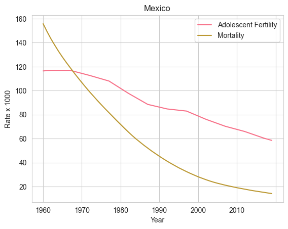

```python
# Graficano
mexico.plot()
plt.title('Mexico')
plt.ylabel('Rate x 1000')
sns.set_palette('husl')
sns.set_style('whitegrid')
```

```python
# Adolescents Fertility in North America
adolescent_na = adolescent_fertility.loc[
    adolescent_fertility['Country Name'].isin(['Mexico',
                                               'United States',
                                               'Canada']),
                                               ['Country Name','2019']]
adolescent_na.set_index('Country Name',inplace=True)
adolescent_na.columns.name = ''
adolescent_na.columns = ['Adolescent Fertility']
adolescent_na
```

| Country Name | Adolescent Fertility |
| --- | --- |
| Canada | 7.6822 |
| Mexico | 58.5434 |
| United States | 17.2524 |

```python
# Mortality in kids in North America
mortality_na = mortality.loc[
    mortality['Country Name'].isin(['Mexico','United States',
                                    'Canada']),['Country Name','2019']]
mortality_na.set_index('Country Name',inplace=True)
mortality_na.columns.name = ''
mortality_na.columns = ['Mortality']
mortality_na
```

| Country Name | Mortality |
| --- | --- |
| Canada | 4.9 |
| Mexico | 14.2 |
| United States | 6.5 |

```python
# North America
north_america = adolescent_na.join(mortality_na)
north_america
```

| Country Name | Adolescent Fertility | Mortality |
| --- | --- | --- |
| Canada | 7.6822 | 4.9 |
| Mexico | 58.5434 | 14.2 |
| United States | 17.2524 | 6.5 |

5. Visualiza el dataframe anterior en un gráfico de barras, ocupando Pandas.

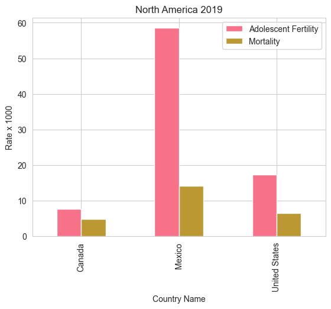

```python
north_america.plot(kind='bar')
plt.title('North America 2019')
plt.ylabel('Rate x 1000')
sns.set_palette('husl')
```

6. Para observar la distribución de ambos indicadores en el mundo, para el 2019, construye un gráfico de histogramas independientes utilizando matplotlib. Utiliza 5 bins y una transparencia de 0.5

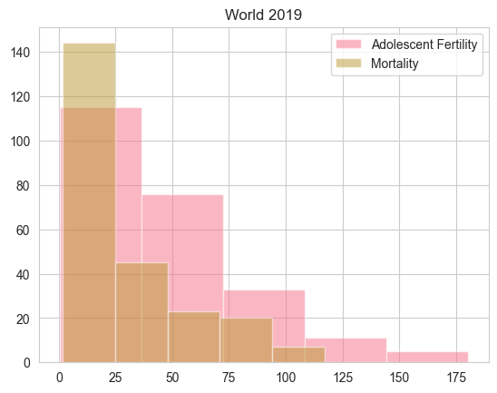

```python
plt.hist('2019',data=adolescent_fertility,
         label='Adolescent Fertility',bins=5,alpha=0.5)
plt.hist('2019',
         label = 'Mortality',data=mortality,bins = 5, alpha=0.5)
plt.title('World 2019')
plt.legend()
```

7. ¿Cómo han cambiado estos índices en la última decada? Compáraldos con boxplots en los años 2009 y 2019.

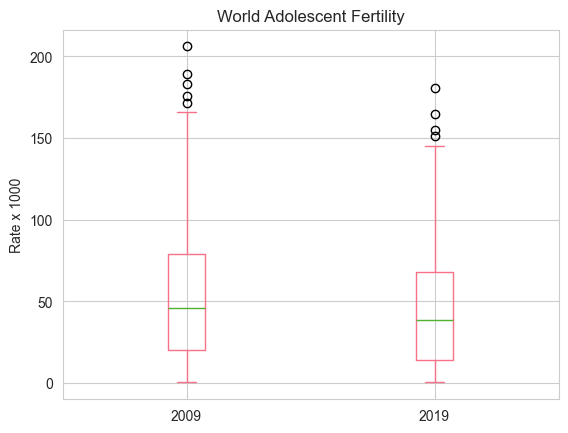

```python
sns.set_palette('husl')
adolescent_fertility[['2009','2019']].plot.box(
    title = 'World Adolescent Fertility',ylabel='Rate x 1000')
```

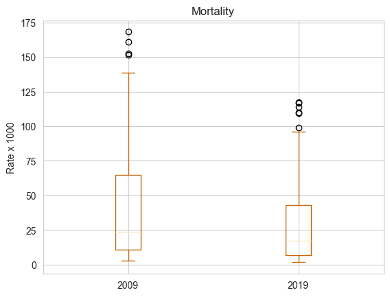

```python
sns.set_palette('PuOr')
mortality[['2009','2019']].plot.box(title='Mortality',
                                    ylabel='Rate x 1000')
```

8. Emplea la plataforma Seaborn para graficar la relación entre las dos tasas en el 2019. También obtén el índice de correlación numérico para cuantificar la dependencia entre ambas variables.

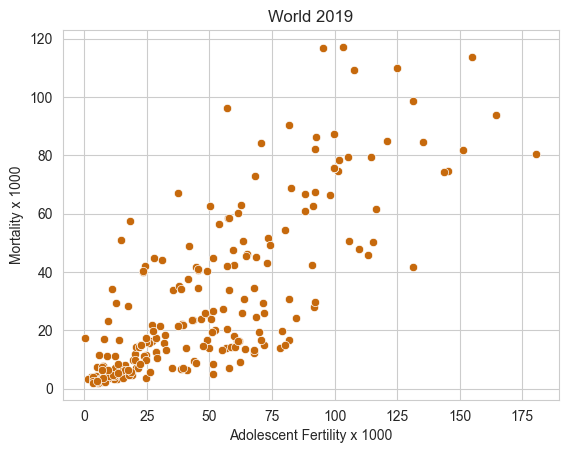

```python
sns.scatterplot(x=adolescent_fertility['2019'],
                y=mortality['2019'])
plt.title('World 2019')
plt.xlabel('Adolescent Fertility x 1000')
plt.ylabel('Mortality x 1000')
```

```python
corr = adolescent_fertility['2019'].corr(mortality['2019'])
corr
```

```
0.7860446246960763
```